# ppg_corrosion_project_feedback

## CMPINF 2100 - Final project feedback

### PPG: corrosion classification

This report gives general feedback based on the proposals about the final project. In addition to addressing pitfalls, multiple recommendations are provided to help with performing the analysis for the project.

## Import modules

```python
import numpy as np
import pandas as pd
import matplotlib.pyplot as plt

import seaborn as sns
```

## Read data

```python
df = pd.read_csv('ppg_corrosion.csv')

df.info()
```

```
<class 'pandas.core.frame.DataFrame'>
RangeIndex: 2000 entries, 0 to 1999
Data columns (total 79 columns):
 #   Column     Non-Null Count  Dtype
---  ------     --------------  -----
 0   X01        2000 non-null   float64
 1   X02        2000 non-null   float64
 2   X03        2000 non-null   float64
 3   X04        2000 non-null   float64
 4   X05        2000 non-null   float64
 5   X06        2000 non-null   float64
 6   X07        2000 non-null   float64
 7   X08        2000 non-null   float64
 8   X09        2000 non-null   float64
 9   X10        2000 non-null   float64
```

[output cut: 71 more lines]

## Comments

### input distributions

It was nice to see the proposals visualize all input distributions! We will look at the input distributions again in this report. The `df` dataframe is reshaped to long-format by "gathering" all inputs together.

```python
input_features = df.select_dtypes('number').copy().columns
```

```python
lf = df.copy().reset_index().rename(columns={'index': 'rowid'}).\
melt(id_vars=['rowid', 'corrosion'], value_vars=input_features, ignore_index=True)
```

The histograms are visualized with separate facets below.

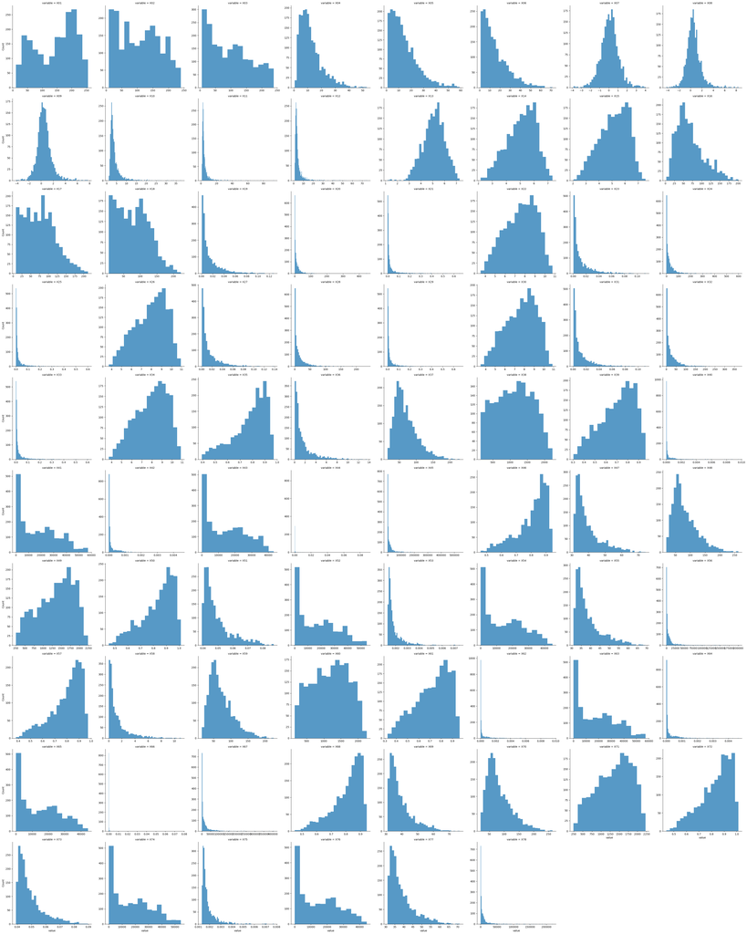

```python
sns.displot(data = lf, x='value', col='variable', kind='hist', col_wrap=8,
            facet_kws={'sharex': False, 'sharey': False},
            common_bins=False)

plt.show()
```

We can see that although some of the distributions have Gaussian-like shapes (e.g. `X07`) most do not! Most are highly skewed with long tails to the right. Long tails to higher values "pull" the mean to be greater than the median. Let's calcualte the skew for all continuous variables in the data set and plot the skew across variables. As we see below many variables have positive skew values. This is consistent with the histograms because positive skew denotes long tails to the right. Skew close to zero corresponds to symmetric distributions.

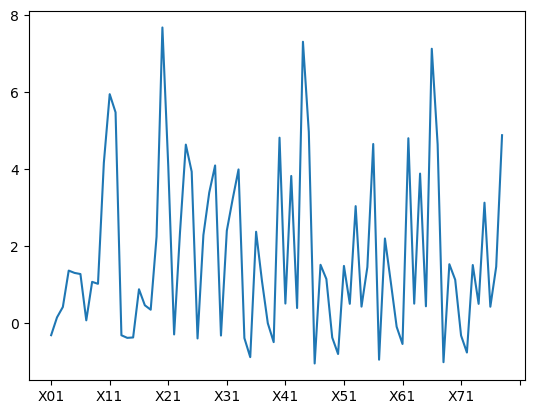

```python
fig, ax = plt.subplots()

df.select_dtypes('number').skew().plot(ax=ax)

plt.show()
```

Let's identify all inputs with skew close to zero. I specified a skew between -0.35 and 0.35 to represent a "small" amount of skew.

```python
small_skew_inputs = input_features[ df.select_dtypes('number').skew().between(-0.35, 0.35, inclusive='both') ]
```

Let's examine the distributions of the roughly symmetric inputs. As we see below, there are relatively few inputs with roughly symmetric distributions.

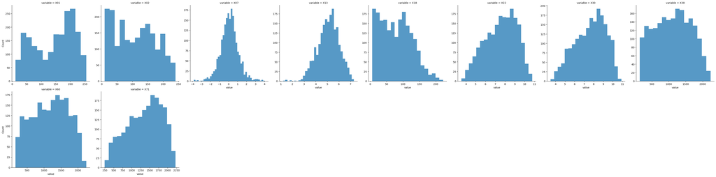

```python
sns.displot(data = lf.loc[ lf.variable.isin( small_skew_inputs ), : ],
            x='value', col='variable', kind='hist', col_wrap=8,
            facet_kws={'sharex': False, 'sharey': False},
            common_bins=False)

plt.show()
```

Let's examine the distributions of the remaining inputs not identified as having a small amount of skew.

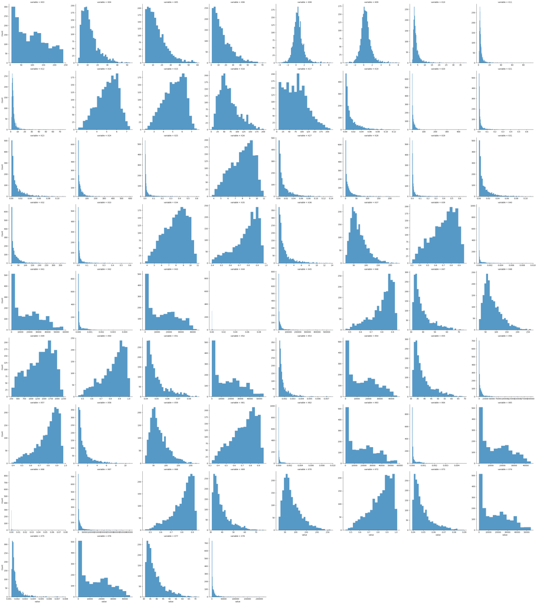

```python
sns.displot(data = lf.loc[ ~lf.variable.isin( small_skew_inputs ), : ],
            x='value', col='variable', kind='hist', col_wrap=8,
            facet_kws={'sharex': False, 'sharey': False},
            common_bins=False)

plt.show()
```

We can try and remove the skew by applying various transformation functions. Common transformations are the natural log, log base 10, log base 2, the square root, and the inverse (the inverse is 1 divided by the variable). These transformation require that the variable does **not** identically equal zero. So it is good to check if variables equal zero. As shown below, **none** of the variables equal zero!

```python
lf.loc[ (lf.value == 0), :].groupby(['variable']).size()
```

```
Series([], dtype: int64)
```

We must also check if the values are negative because the log and square root transformations do not work with negative values. As we see below, only `X08` and `X09` have negative numbers

```python
lf.loc[ (~lf.variable.isin(small_skew_inputs)) & (lf.value < 0), :].groupby(['variable']).size()
```

```
variable
X08    627
X09    630
dtype: int64
```

For simplicity, let's remove those two inputs from the set of skewed distributions.

```python
lf_skew = lf.loc[ ~lf.variable.isin(small_skew_inputs), :].copy()

lf_skew = lf_skew.loc[ ~lf_skew.variable.isin(['X08', 'X09']), :].copy()
```

Let's apply the natural log transformation to the skewed variables.

```python
lf_skew['log_value'] = np.log( lf_skew.value )
```

As we see below some of the distributions look more symmetric!

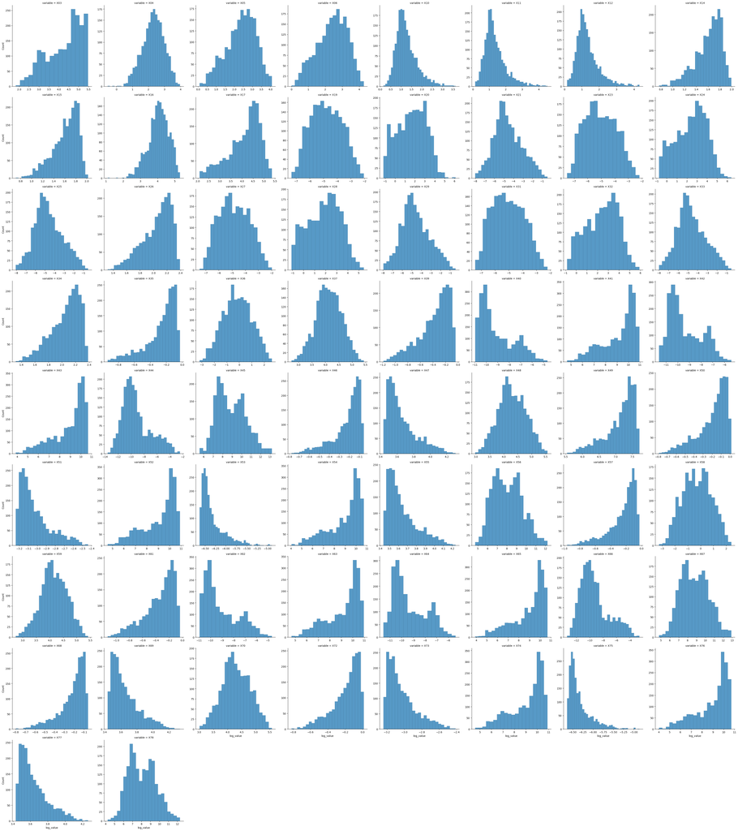

```python
sns.displot(data = lf_skew,
            x='log_value', col='variable', kind='hist', col_wrap=8,
            facet_kws={'sharex': False, 'sharey': False},
            common_bins=False)

plt.show()
```

Not all of the distributions have the skew removed by applying the natural log transformation. Let's try another transformation by inverting the value.

```python
lf_skew['inverse_value'] = 1 / lf_skew.value
```

The distributions of the inverted values are below. The inverse did not seem to help out all that much.

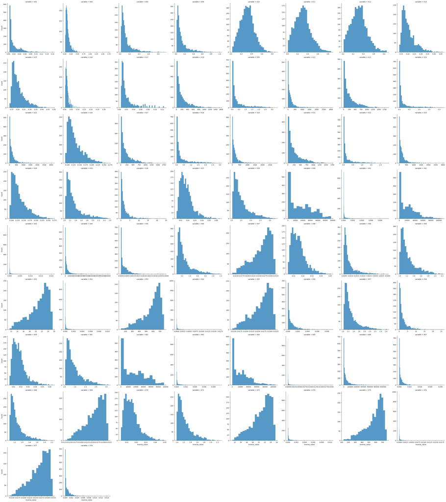

```python
sns.displot(data = lf_skew,
            x='inverse_value', col='variable', kind='hist', col_wrap=8,
            facet_kws={'sharex': False, 'sharey': False},
            common_bins=False)

plt.show()
```

Some of the variables appear more symmetric, while most do not! As with the natural log-transformation, the inverse transformation does not fix the problem for all variables!

Finally, let's try the square root.

```python
lf_skew['sqrt_value'] = np.sqrt( lf_skew.value )
```

Several of the inputs now have more symmetric distributions based on applying the square root transformation compared with the other transformations that we tried. However, as with the other transformations the square root does not "fix" the issue for all variables!

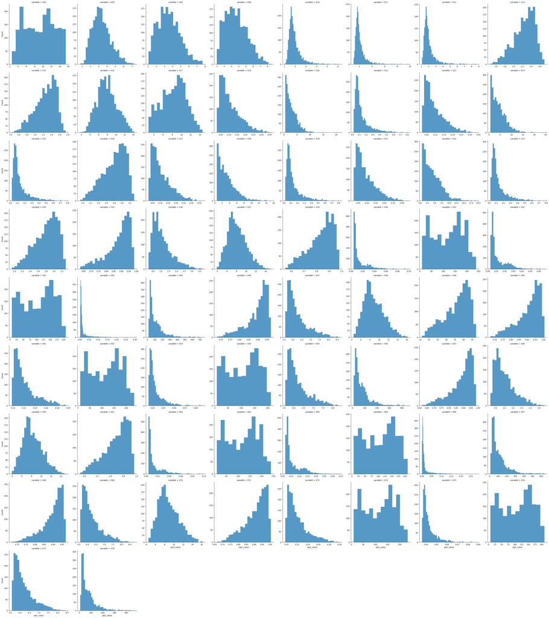

```python
sns.displot(data = lf_skew,
            x='sqrt_value', col='variable', kind='hist', col_wrap=8,
            facet_kws={'sharex': False, 'sharey': False},
            common_bins=False)

plt.show()
```

**Why does this matter?**

Highly skewed distributions can be challenging to work with. For clustering problems, it is easier to not have the variables "piling up" or being "pushed" to a bound. The distance calculations prefer to have symmetric distributions. Similar issues occur with fitting linear regression and logistic regression models. It can help the model behavior if the inputs distributions are symmetric.

It was good to see that the proposals also examined the correlation structure between the many inputs and considered applying PCA to reduce the dimensionality of the problem. PCA can sometimes also benefit by working with symmetric distributions rather than highly skewed distributions.

In summary, this report provides several options for removing skew and you should apply the transformations in your analysis. As this report showed earlier, some transformations work better for some variables than others. You may use different transformations for the different inputs or you may apply the same transformation to all inputs. The choice is yours for the project.

Based on this report though, you might be thinking none of these transformations are perfect. None of these transformations can truly "solve" the problem. You are correct! One definite method does **not** always work for all situtations. This is the reality of modeling! However, there are general approaches that attempt to create an *optimal* transformation to remove skew. Several such approaches are the Box-Cox, Yeo-Johnson, and Quantile transformations. These more advanced procedures are beyond the scope of CMPINF 2100. They are discussed and demonstrated in CMPINF 2120. Therefore, if you continue in the ADDM courses you will see these more advanced **pre-processing** methods. For now though, what matters is that you try a transformation and see the impact the of the approach on your models.

### PCA and classification model fitting

The key to this project is PCA because the inputs are so highly correlated. Although we discussed PCA up to this point as a tool to help with visualization and data exploration, PCA can also be used to extract features for models. Thus, PCA can be viewed as a **pre-processing** step for predictive models! This lets the models work with uncorrelated features rather than correlated features. The last few modules will show how to create data analysis pipelines of applying PCA and fitting models with PCA features. However, to get started manually perform PCA and use the PC scores as features to the binary classifiers. Start by performing PCA on the original variables. Then try out various transformation functions on the variables and reperform PCA. Select the number of PCs to use as features in the model based on the standard deviation or variance of the PCs. Keep all PCs that seem to have a meaningful amount of variance, similar to "knee bend" plot in clustering. CMPINF 2120 discusses PCA in much more detail so that you will learn just how to select the appropriate number of PCs.